# Stat 615 Final_Project

# 3 Full Regression Model

- full regression model including both categorical and quantitative variables

```r
lm(charges ~ age + children + bmi + region + sex + smoker,data = insurance_new) -> x
x
```

```
##
## Call:
## lm(formula = charges ~ age + children + bmi + region + sex +
##     smoker, data = insurance_new)
##
## Coefficients:
##     (Intercept)              age         children              bmi
##        -12033.2            261.1            532.8            353.3
## regionnorthwest  regionsoutheast  regionsouthwest          sexmale
##         -1545.5          -1505.4          -1719.9            607.8
##       smokeryes
##         22876.4
```

# 4 Matrix

## 4.1 Fitted & Residual values using matrix for quantitative variables

```r
Xm <-  model.matrix(~age + children + bmi   , data=insurance_new )
Ym <- as.matrix(insurance_new%>%dplyr::select(charges))
# Let's use R code to establish matrix X :
#-------------------------------------------------------------------
#  A = (X^T*X)^-1*X^TY
(solve(t(Xm)%*%Xm))%*%(t(Xm)%*%Ym)
```

```
##                charges
## (Intercept) -4825.6927
## age           185.6491
## children      669.1986
## bmi           333.8682
```

```r
#-------------------------------------------------------------------
# fitted values
Xm%*%((solve(t(Xm)%*%Xm))%*%(t(Xm)%*%Ym)) -> fitted_values
#-------------------------------------------------------------------
# residual values
Ym-Xm%*%((solve(t(Xm)%*%Xm))%*%(t(Xm)%*%Ym)) -> residual_values
#-------------------------------------------------------------------
# producing the table of residula and fitted plot for the model.
matrix = data.frame(fitted_values, residual_values)
names(matrix)[1] <- "fitted_values"
names(matrix)[2] <- "residual_values"
head(matrix, 6)
```

```
##   fitted_values residual_values
## 1     15243.617       -989.0085
## 2     11259.742      25048.0563
## 3     13967.964       7264.2178
## 4     15547.919      -7307.3293
## 5     15580.081      -5855.5505
## 6      8486.629      -3028.5827
```

```r
#-------------------------------------------------------------------
# Both fitted values and residual values match with matrix model
lm(charges ~ age + children + bmi, data= insurance_new) -> AB
#summary(AB)
#residuals(AB)
#fitted(AB)
```

## 4.2 Matrix method with both quantitative and qualitative variables(dummy variables included automatically)

```r
# The results are the same using both the matrix method and lm method.

Xm <-  model.matrix(~age + children + bmi + region + sex+ smoker  , data=insurance_new )
Ym <- as.matrix(insurance_new%>%dplyr::select(charges))

# Let's use R code to establish matrix X :
#-------------------------------------------------------------------
#  A = (X^T*X)^-1*X^TY
(solve(t(Xm)%*%Xm))%*%(t(Xm)%*%Ym)
```

```
##                     charges
## (Intercept)     -12033.2491
## age                261.1443
## children           532.7552
## bmi                353.3493
## regionnorthwest  -1545.5302
## regionsoutheast  -1505.3521
## regionsouthwest  -1719.9011
## sexmale            607.7807
## smokeryes        22876.3789
```

```r
#-------------------------------------------------------------------
# fitted values
Xm%*%((solve(t(Xm)%*%Xm))%*%(t(Xm)%*%Ym)) -> fitted_values
#-------------------------------------------------------------------
# residual values
Ym-Xm%*%((solve(t(Xm)%*%Xm))%*%(t(Xm)%*%Ym)) -> residual_values
#-------------------------------------------------------------------
# producing the table of residula and fitted plot for the model.
matrix = data.frame(fitted_values, residual_values)
names(matrix)[1] <- "fitted_values"
names(matrix)[2] <- "residual_values"
head(matrix,6)
```

```
##   fitted_values residual_values
## 1     11735.311        2519.298
## 2     28133.497        8174.301
## 3      9848.695       11383.488
## 4     10822.791       -2582.201
## 5     11638.037       -1913.507
## 6      4383.695        1074.351
```

```r
#-------------------------------------------------------------------
# Both fitted values and residual values match with matrix model
lm(charges ~ age + children + bmi+ region + sex + smoker, data= insurance_new) -> AB
#summary(AB)
#residuals(AB)
#fitted(AB)
```

# 5 Analyze and Evaluate the full model

```r
lm(charges ~ age + children + bmi+ region + sex + smoker, data= insurance_new) -> AB
summary(AB)
```

```
##
## Call:
## lm(formula = charges ~ age + children + bmi + region + sex +
##     smoker, data = insurance_new)
##
## Residuals:
##    Min     1Q Median     3Q    Max
## -10712  -3120  -1095   1496  24152
##
## Coefficients:
##                  Estimate Std. Error t value Pr(>|t|)
## (Intercept)     -12033.25    2155.91  -5.582 5.46e-08 ***
## age                261.14      24.05  10.858  < 2e-16 ***
## children           532.76     279.27   1.908   0.0574 .
## bmi                353.35      62.03   5.696 2.99e-08 ***
## regionnorthwest  -1545.53     992.47  -1.557   0.1205
## regionsoutheast  -1505.35    1036.22  -1.453   0.1474
## regionsouthwest  -1719.90     990.21  -1.737   0.0835 .
## sexmale            607.78     694.59   0.875   0.3823
## smokeryes        22876.38     865.37  26.435  < 2e-16 ***
## ---
## Signif. codes:  0 '***' 0.001 '**' 0.01 '*' 0.05 '.' 0.1 ' ' 1
##
## Residual standard error: 5915 on 291 degrees of freedom
## Multiple R-squared:  0.7379, Adjusted R-squared:  0.7307
## F-statistic: 102.4 on 8 and 291 DF,  p-value: < 2.2e-16
```

## 5.1 Coefficients:

### charges = -12033.25 + (age)*261.14 + (children)*532.76 + (bmi)*353.35 + (region_northwest)(-1545.53) + (region_southeast)*(-1505.35) + (regionsouthwest)*(-1719.90) + (sexmale)*(607.78) + (smokeryes)*(22876.38)

- The **Estimate column** lists the estimated coefficients of the predictor variables included in the model. For instance, the “age” coefficient has an estimated value of 261.14, which means that for every one-unit increase in age, the outcome variable (presumably a medical cost) is estimated to increase by $261.14, holding all other variables constant.

## 5.2 Standard Errors:

- The **Std Error** column lists the standard errors of the estimated coefficients. These are measures of the uncertainty or variability in the estimated coefficients. Smaller standard errors indicate more precise estimates.

## 5.3 T-values:

- The **t-value** column lists the t-statistics for each coefficient. These values represent the estimated coefficients divided by their standard errors. T-values are used to test the null hypothesis that the true coefficient is zero. Larger t-values indicate a stronger evidence against the null hypothesis.

## 5.5 Residual Standard Error:

- The **Residual standard error** provides an estimate of the variability of the errors or unexplained variance in the model. It measures the average distance that the observed values fall from the predicted values.

## 5.6 R-squared:

- The “Multiple R-squared” and “Adjusted R-squared” measures how well the model fits the data. R-squared ranges from 0 to 1 and represents the proportion of variance in the outcome variable that is explained by the predictor variables. Adjusted R-squared is a corrected version of R-squared that takes into account the number of predictor variables in the model. In full model one can see 0.7379.

## 5.7 summary

- This data summary provides information on the estimated coefficients, their standard errors, t-values, and corresponding p-values, as well as model diagnostics such as residual standard error, multiple R-squared, adjusted R-squared, and F-statistic. These measures can be used to interpret the strength and significance of the relationship between the predictor variables and the outcome variable, as well as the overall goodness-of-fit of the model. Still working to find the best parameters to be included in the model.

# 6 Confidence intervals for all variables used in full model

- These intervals provide a range of plausible values for the true population coefficients based on the sample data. The first column, “2.5%”, represents the lower bound of the interval, and the second column, “97.5%”, represents the upper bound of the interval.
- The 95% confidence interval for the “age” variable is [213.81, 308.48]. This means that we are 95% confident that the true population coefficient for age falls within this range. Similarly, the confidence interval for the intercept is [-16276.39, -7790.11], which suggests that the expected value of the response variable (when all predictor variables are 0) is likely to be within this range.

```r
confint(AB,level = 0.95)
```

```
##                        2.5 %     97.5 %
## (Intercept)     -16276.39288 -7790.1053
## age                213.80684   308.4817
## children           -16.88546  1082.3959
## bmi                231.26578   475.4327
## regionnorthwest  -3498.86525   407.8049
## regionsoutheast  -3544.78722   534.0830
## regionsouthwest  -3668.78747   228.9853
## sexmale           -759.27612  1974.8375
## smokeryes        21173.19777 24579.5601
```

# 7 Full and Reduced Model for transformed variables with interaction terms

## 7.1 Evaluating Various regression models.

- Let us begin by using a multiple linear regression model that uses all the six variables. From the summary table we see that our R squared and Adjusted r square are around 0.73 and the residual standard error is 5915. The r squared value is high enough to be considered good but let us continue finding better fits.

```r
ols_step_all_possible(AB) ->  allmodels
as_tibble(allmodels) -> allmodels_1
tail(allmodels_1,8)
```

```
## # A tibble: 8 × 14
##   mindex     n predict…¹ rsquare   adjr predrsq     cp   aic  sbic   sbc    msep
##    <int> <int> <chr>       <dbl>  <dbl>   <dbl>  <dbl> <dbl> <dbl> <dbl>   <dbl>
## 1     56     4 children…  0.0470 0.0275 0.00150 768.   6457. 5593. 6486. 3.77e10
## 2     57     5 age chil…  0.737  0.731  0.721     3.77 6072. 5217. 6105. 1.04e10
## 3     58     5 age bmi …  0.735  0.728  0.718     6.64 6075. 5220. 6108. 1.05e10
## 4     59     5 age chil…  0.735  0.730  0.722     6.70 6071. 5220. 6097. 1.05e10
## 5     60     5 age chil…  0.709  0.702  0.690    35.4  6103. 5247. 6136. 1.15e10
## 6     61     5 children…  0.632  0.623  0.609   121.   6173. 5315. 6207. 1.46e10
## 7     62     5 age chil…  0.109  0.0873 0.0600  702.   6439. 5574. 6472. 3.53e10
## 8     63     6 age chil…  0.738  0.731  0.720     5    6073. 5218. 6110. 1.04e10
## # … with 3 more variables: fpe <dbl>, apc <dbl>, hsp <dbl>, and abbreviated
## #   variable name ¹predictors
```

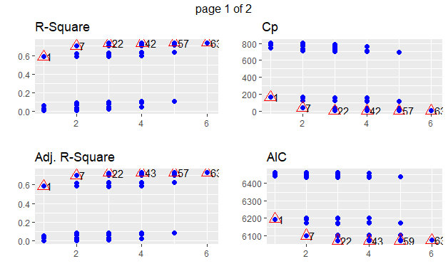

```r
# the best model is represented by including all age, children,bmi, region, smoker full model.
knitr::include_graphics("./1.png")
```

```r
# plot(allmodels)
```

## 7.2 Finding Reduced and full model using interaction terms

- Let us see how r will create dummy variables for us using Region variable. R will convert the categorical variables for us We can see R will do this automatically for us creating these dummy variables. Northeast is essentially the control variable. When the three variables are 0, it means that region is northeast! No need to bother here as R does this for us.

```r
contrasts(as.factor(insurance_new$region))
```

```
##           northwest southeast southwest
## northeast         0         0         0
## northwest         1         0         0
## southeast         0         1         0
## southwest         0         0         1
```

```r
# Next step - Let us include all the interaction terms as well. Our residual standard error reduced. significantly to 4910. Our R squared also increased to 0.8331.

lm(charges~ age + children + bmi +
     region + sex + smoker + age:children + age:bmi + age:region + age:sex + age:smoker+
     children:bmi + children:region + children:sex + children:smoker
     + bmi:region + bmi:sex+ bmi:smoker + region:sex + region + smoker
   + sex:smoker, insurance_new) -> interactionModel
summary(interactionModel)
```

```
##
## Call:
## lm(formula = charges ~ age + children + bmi + region + sex +
##     smoker + age:children + age:bmi + age:region + age:sex +
##     age:smoker + children:bmi + children:region + children:sex +
##     children:smoker + bmi:region + bmi:sex + bmi:smoker + region:sex +
##     region + smoker + sex:smoker, data = insurance_new)
##
## Residuals:
##     Min      1Q  Median      3Q     Max
## -8196.3 -2253.3 -1060.8   274.9 20420.1
##
## Coefficients:
##                            Estimate Std. Error t value Pr(>|t|)
## (Intercept)               -2834.483   5950.715  -0.476 0.634228
## age                         146.188    117.074   1.249 0.212868
## children                    -52.254   1533.089  -0.034 0.972835
## bmi                          98.895    196.858   0.502 0.615821
## regionnorthwest            4940.926   5420.759   0.911 0.362857
## regionsoutheast            1791.263   5455.771   0.328 0.742922
## regionsouthwest             485.686   5074.751   0.096 0.923825
## sexmale                   -1228.344   3662.175  -0.335 0.737574
## smokeryes                -17140.502   4375.582  -3.917 0.000114 ***
## age:children                 25.113     18.782   1.337 0.182338
## age:bmi                       1.850      3.667   0.504 0.614324
## age:regionnorthwest          60.038     59.631   1.007 0.314922
## age:regionsoutheast          69.054     61.319   1.126 0.261106
## age:regionsouthwest          98.009     58.561   1.674 0.095368 .
## age:sexmale                 -22.156     41.292  -0.537 0.592007
## age:smokeryes               -57.725     53.308  -1.083 0.279845
## children:bmi                -13.009     43.378  -0.300 0.764478
## children:regionnorthwest    105.184    740.993   0.142 0.887226
## children:regionsoutheast   -318.240    763.888  -0.417 0.677299
## children:regionsouthwest   -233.540    712.265  -0.328 0.743255
## children:sexmale            553.118    487.168   1.135 0.257230
## children:smokeryes        -1218.854    638.980  -1.908 0.057521 .
## bmi:regionnorthwest        -260.593    159.656  -1.632 0.103803
## bmi:regionsoutheast        -120.067    154.970  -0.775 0.439153
## bmi:regionsouthwest        -161.455    156.511  -1.032 0.303190
## bmi:sexmale                 105.175    108.360   0.971 0.332616
## bmi:smokeryes              1459.039    134.821  10.822  < 2e-16 ***
## regionnorthwest:sexmale    -915.301   1733.496  -0.528 0.597929
## regionsoutheast:sexmale   -3533.510   1791.412  -1.972 0.049580 *
## regionsouthwest:sexmale   -2069.808   1698.494  -1.219 0.224059
## sexmale:smokeryes          -380.218   1604.912  -0.237 0.812908
## ---
## Signif. codes:  0 '***' 0.001 '**' 0.01 '*' 0.05 '.' 0.1 ' ' 1
##
## Residual standard error: 4910 on 269 degrees of freedom
## Multiple R-squared:  0.8331, Adjusted R-squared:  0.8144
## F-statistic: 44.75 on 30 and 269 DF,  p-value: < 2.2e-16
```

```r
# Let us also see if transforming our dependent variable might help. Our R squared increased slightly
# but not much

lm(log(charges)~ age + children + bmi +
     region + sex + smoker + age:children + age:bmi + age:region + age:sex + age:smoker+
     children:bmi + children:region + children:sex + children:smoker
   + bmi:region + bmi:sex+ bmi:smoker + region:sex + region + smoker
   + sex:smoker, insurance_new) -> interactionModel
summary(interactionModel)
```

```
##
## Call:
## lm(formula = log(charges) ~ age + children + bmi + region + sex +
##     smoker + age:children + age:bmi + age:region + age:sex +
##     age:smoker + children:bmi + children:region + children:sex +
##     children:smoker + bmi:region + bmi:sex + bmi:smoker + region:sex +
##     region + smoker + sex:smoker, data = insurance_new)
##
## Residuals:
##      Min       1Q   Median       3Q      Max
## -0.56846 -0.16881 -0.07365  0.03661  2.07636
##
## Coefficients:
##                            Estimate Std. Error t value Pr(>|t|)
## (Intercept)               6.5081702  0.4688489  13.881  < 2e-16 ***
## age                       0.0404944  0.0092241   4.390 1.63e-05 ***
## children                  0.2323820  0.1207900   1.924 0.055428 .
## bmi                       0.0373892  0.0155102   2.411 0.016596 *
## regionnorthwest           0.1858655  0.4270944   0.435 0.663776
## regionsoutheast           0.0443852  0.4298529   0.103 0.917836
## regionsouthwest          -0.1660037  0.3998328  -0.415 0.678339
## sexmale                  -0.3419357  0.2885379  -1.185 0.237038
## smokeryes                 1.5843978  0.3447462   4.596 6.63e-06 ***
## age:children             -0.0027142  0.0014798  -1.834 0.067741 .
## age:bmi                  -0.0003435  0.0002889  -1.189 0.235491
## age:regionnorthwest       0.0125558  0.0046982   2.672 0.007990 **
## age:regionsoutheast       0.0145449  0.0048312   3.011 0.002855 **
## age:regionsouthwest       0.0165099  0.0046140   3.578 0.000410 ***
## age:sexmale               0.0040348  0.0032533   1.240 0.215983
## age:smokeryes            -0.0353317  0.0042001  -8.412 2.40e-15 ***
## children:bmi             -0.0004008  0.0034177  -0.117 0.906735
## children:regionnorthwest -0.0022434  0.0583819  -0.038 0.969377
## children:regionsoutheast -0.0215457  0.0601857  -0.358 0.720634
## children:regionsouthwest -0.0263279  0.0561184  -0.469 0.639343
## children:sexmale          0.0645546  0.0383833   1.682 0.093760 .
## children:smokeryes       -0.1738442  0.0503443  -3.453 0.000644 ***
## bmi:regionnorthwest      -0.0287379  0.0125790  -2.285 0.023116 *
## bmi:regionsoutheast      -0.0213882  0.0122099  -1.752 0.080963 .
## bmi:regionsouthwest      -0.0213983  0.0123313  -1.735 0.083835 .
## bmi:sexmale               0.0049372  0.0085376   0.578 0.563549
## bmi:smokeryes             0.0495150  0.0106224   4.661 4.95e-06 ***
## regionnorthwest:sexmale   0.0331110  0.1365798   0.242 0.808632
## regionsoutheast:sexmale  -0.2677983  0.1411430  -1.897 0.058852 .
## regionsouthwest:sexmale  -0.1418041  0.1338221  -1.060 0.290256
## sexmale:smokeryes         0.0337446  0.1264488   0.267 0.789778
## ---
## Signif. codes:  0 '***' 0.001 '**' 0.01 '*' 0.05 '.' 0.1 ' ' 1
##
## Residual standard error: 0.3869 on 269 degrees of freedom
## Multiple R-squared:  0.8363, Adjusted R-squared:  0.818
## F-statistic: 45.81 on 30 and 269 DF,  p-value: < 2.2e-16
```